# SI 618 Day 9: Dimension Reduction

Version 2023.03.07.3.CT

## Task (to generate data for use later in today's class):

Fill in the [spreadsheet](https://docs.google.com/spreadsheets/d/178npckIJAcp0vY2TEmg9Sn3sJYUYYDSAmw8_ouxZR7A/edit?usp=sharing) with your music preferences. Rate each genre on a scale of 1 to 10, with 1 being "no way" and 10 being "the best". Note that you are indicating your preference for each genre on a scale of 1-10; you are not ranking the genres from 1-10. Thus, you can have all 10s if you love all genres of music, or all 1s if you hate music in general.

Install Open CV package: pip install opencv-python, Install plotly : pip install plotly

```python
import pandas as pd
import numpy as np
import seaborn as sns
import matplotlib.pyplot as plt
from sklearn import manifold
```

Let's set up a really simple dataframe to play with:

```python
demo = pd.DataFrame({'a': [1, 2, 3, 1], 'b': [1, 4, 6, 1], 'c': [2, 4, 6, 3]},
                    index=['Chris', 'Xin', 'Arjun', 'Buko'])
```

```python
demo
```

|  | a | b | c |
| --- | --- | --- | --- |
| Chris | 1 | 1 | 2 |
| Xin | 2 | 4 | 4 |
| Arjun | 3 | 6 | 6 |
| Buko | 1 | 1 | 3 |

And then let's split the dataframe into X and y matrices:

```python
demo_X = demo.values
```

```python
demo_X
```

```
array([[1, 1, 2],
       [2, 4, 4],
       [3, 6, 6],
       [1, 1, 3]])
```

```python
demo_y = demo.index
```

```python
demo_y
```

```
Index(['Chris', 'Xin', 'Arjun', 'Buko'], dtype='object')
```

## Multi-dimensional scaling (MDS)

```python
nmds = manifold.MDS(n_components=2,
                    metric=False,
                    max_iter=3000,
                    eps=1e-9,
                    random_state=42,
                    dissimilarity='euclidean',
                    normalized_stress='auto',
                    n_jobs=1)
```

```python
npos = nmds.fit_transform(demo_X)
```

```python
npos
```

```
array([[-0.25640198,  0.45035412],
       [ 0.10299116, -0.125423  ],
       [ 0.43708603, -0.41819504],
       [-0.28367521,  0.09326392]])
```

```python
npos_labelled = pd.concat([pd.DataFrame({'who': demo_y}), pd.DataFrame(npos)], axis=1)
```

```python
npos_labelled.columns = ['who', 'mds1', 'mds2']
```

```python
npos_labelled
```

|  | who | mds1 | mds2 |
| --- | --- | --- | --- |
| 0 | Chris | -0.256402 | 0.450354 |
| 1 | Xin | 0.102991 | -0.125423 |
| 2 | Arjun | 0.437086 | -0.418195 |
| 3 | Buko | -0.283675 | 0.093264 |

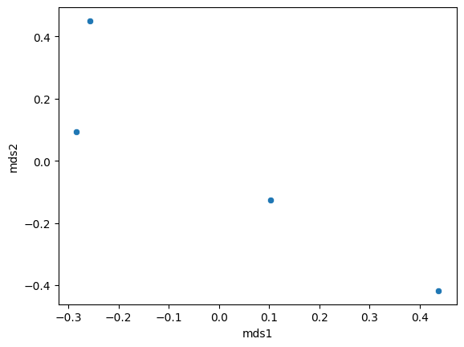

```python
p1 = sns.scatterplot(data=npos_labelled, x='mds1', y='mds2')
```

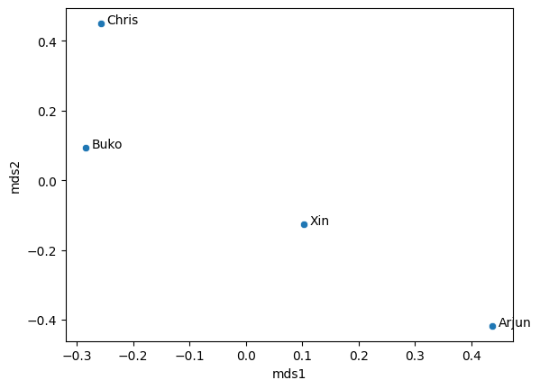

```python
# Based on https://stackoverflow.com/questions/46027653/adding-labels-in-x-y-scatter-plot-with-seaborn
p1 = sns.scatterplot(data=npos_labelled, x='mds1', y='mds2')
for line in range(0, npos_labelled.shape[0]):
     p1.text(npos_labelled['mds1'][line]+0.01, npos_labelled['mds2'][line],
     npos_labelled['who'][line], horizontalalignment='left',
     size='medium', color='black')
```

```python
def labelled_scatterplot(data=None,x=None,y=None,labs=None):
    p1 = sns.scatterplot(data=data,x=x,y=y)
    for line in range(0,data.shape[0]):
        if data[labs][line] == 'Chris T':
            c = 'red'
        else:
            c = 'black'
        p1.text(data[x][line]+0.01, data[y][line],
                data[labs][line], horizontalalignment='left',
                size='medium', color=c)
```

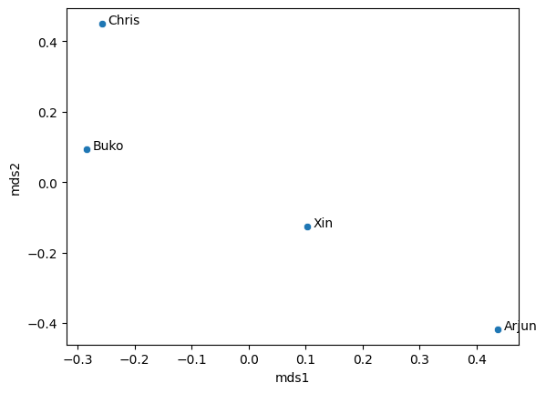

```python
labelled_scatterplot(npos_labelled,'mds1','mds2','who')
```

EXAMPLE 2

```python
df = pd.DataFrame({'player': ['A', 'B', 'C', 'D', 'E', 'F', 'G', 'H', 'I', 'J', 'K'],
                   'points': [4, 4, 6, 7, 8, 14, 16, 19, 25, 25, 28],
                   'assists': [3, 2, 2, 5, 4, 8, 7, 6, 8, 10, 11],
                   'blocks': [7, 3, 6, 7, 5, 8, 8, 4, 2, 2, 1],
                   'rebounds': [4, 5, 5, 6, 5, 8, 10, 4, 3, 2, 2]})
```

```python
df = df.set_index('player')
```

```python
df.head()
```

| player | points | assists | blocks | rebounds |
| --- | --- | --- | --- | --- |
| A | 4 | 3 | 7 | 4 |
| B | 4 | 2 | 3 | 5 |
| C | 6 | 2 | 6 | 5 |
| D | 7 | 5 | 7 | 6 |
| E | 8 | 4 | 5 | 5 |

```python
X = df.values
y = df.index
npos = nmds.fit_transform(X)
npos
```

```
array([[-0.19175961,  0.11334459],
       [-0.20035458,  0.30754401],
       [ 0.22301044, -0.06627027],
       [-0.37198597,  0.27169808],
       [-0.10256325,  0.39072683],
       [ 0.44084649, -0.56102777],
       [ 0.15362031, -0.46778332],
       [ 0.54838192,  0.04812215],
       [-0.27120714, -0.42027557],
       [-0.36834069, -0.10463543],
       [ 0.2884843 ,  0.38548271]])
```

```python
npos_labelled = pd.concat([pd.DataFrame({'who': y}), pd.DataFrame(npos)], axis=1)
npos_labelled
```

|  | who | 0 | 1 |
| --- | --- | --- | --- |
| 0 | A | -0.191760 | 0.113345 |
| 1 | B | -0.200355 | 0.307544 |
| 2 | C | 0.223010 | -0.066270 |
| 3 | D | -0.371986 | 0.271698 |
| 4 | E | -0.102563 | 0.390727 |
| 5 | F | 0.440846 | -0.561028 |
| 6 | G | 0.153620 | -0.467783 |
| 7 | H | 0.548382 | 0.048122 |
| 8 | I | -0.271207 | -0.420276 |
| 9 | J | -0.368341 | -0.104635 |
| 10 | K | 0.288484 | 0.385483 |

```python
npos_labelled.columns = ['who', 'mds1', 'mds2']
```

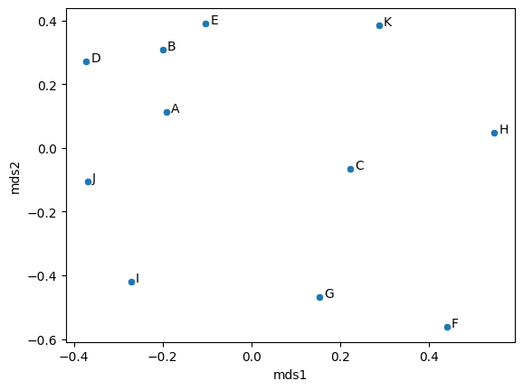

```python
labelled_scatterplot(npos_labelled,'mds1','mds2','who')
```

## Principal Components Analysis (PCA)

```python
demo
```

|  | a | b | c |
| --- | --- | --- | --- |
| Chris | 1 | 1 | 2 |
| Xin | 2 | 4 | 4 |
| Arjun | 3 | 6 | 6 |
| Buko | 1 | 1 | 3 |

```python
from sklearn.preprocessing import scale
scale(demo_X)
```

```
array([[-0.90453403, -0.94280904, -1.18321596],
       [ 0.30151134,  0.47140452,  0.16903085],
       [ 1.50755672,  1.41421356,  1.52127766],
       [-0.90453403, -0.94280904, -0.50709255]])
```

```python
np.var([-1.29777, .016222, 1.135549])
```

```
0.9889454738615555
```

```python
from sklearn.decomposition import PCA

pca = PCA(n_components=2)
X_pca = pca.fit_transform(scale(demo_X))
```

```python
X_pca
```

```
array([[-1.74849588, -0.21383124],
       [ 0.54456683, -0.1913689 ],
       [ 2.56500363,  0.07178607],
       [-1.36107457,  0.33341407]])
```

```python
X_pca_labelled = pd.concat([pd.DataFrame({'who':demo_y}),pd.DataFrame(X_pca,columns=['pca1','pca2'])],axis=1)
```

```python
X_pca_labelled
```

|  | who | pca1 | pca2 |
| --- | --- | --- | --- |
| 0 | Chris | -1.748496 | -0.213831 |
| 1 | Xin | 0.544567 | -0.191369 |
| 2 | Arjun | 2.565004 | 0.071786 |
| 3 | Buko | -1.361075 | 0.333414 |

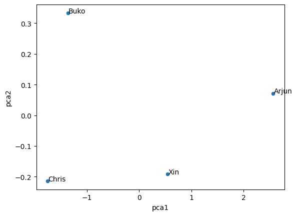

```python
labelled_scatterplot(data=X_pca_labelled,x='pca1',y='pca2',labs='who')
```

```python
pca.explained_variance_
```

```
array([3.9285195 , 0.06622135])
```

```python
np.cov(X_pca)
```

```
array([[ 1.17759778, -0.56470727, -1.91312642,  1.3002359 ],
       [-0.56470727,  0.2708007 ,  0.91742394, -0.62351737],
       [-1.91312642,  0.91742394,  3.10806691, -2.11236443],
       [ 1.3002359 , -0.62351737, -2.11236443,  1.43564589]])
```

```python
pca.explained_variance_ratio_
```

```
array([0.98212987, 0.01655534])
```

### Question:

What's the expected explained variance ratio for each variable?

IMAGE Compression with PCA

```python
import cv2
```

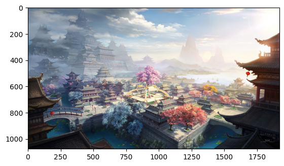

```python
img = cv2.cvtColor(cv2.imread('./bg.png'), cv2.COLOR_BGR2RGB)
plt.imshow(img)
plt.show()
```

```python
img.shape
```

```
(1077, 1920, 3)
```

[figure not shown]

```python
#Splitting into channels
blue,green,red = cv2.split(img)
# Plotting the images
fig = plt.figure(figsize = (15, 7.2))
fig.add_subplot(131)
plt.title("Blue Channel")
plt.imshow(blue)
fig.add_subplot(132)
plt.title("Green Channel")
plt.imshow(green)
fig.add_subplot(133)
plt.title("Red Channel")
plt.imshow(red)
plt.show()
```

```python
blue_temp_df = pd.DataFrame(data = blue)
blue_temp_df
```

|  | 0 | 1 | 2 | 3 | 4 | 5 | 6 | 7 | 8 | 9 | ... | 1910 | 1911 | 1912 | 1913 | 1914 | 1915 | 1916 | 1917 | 1918 | 1919 |
| --- | --- | --- | --- | --- | --- | --- | --- | --- | --- | --- | --- | --- | --- | --- | --- | --- | --- | --- | --- | --- | --- |
| 0 | 91 | 91 | 91 | 92 | 93 | 92 | 90 | 89 | 91 | 91 | ... | 255 | 255 | 255 | 255 | 255 | 255 | 255 | 255 | 255 | 255 |
| 1 | 91 | 91 | 92 | 93 | 93 | 92 | 91 | 89 | 92 | 92 | ... | 255 | 255 | 255 | 255 | 255 | 255 | 255 | 255 | 255 | 255 |
| 2 | 92 | 92 | 93 | 93 | 94 | 93 | 92 | 91 | 92 | 92 | ... | 254 | 254 | 255 | 255 | 255 | 255 | 255 | 255 | 255 | 255 |
| 3 | 93 | 93 | 94 | 94 | 95 | 95 | 94 | 93 | 93 | 93 | ... | 254 | 254 | 255 | 255 | 255 | 255 | 255 | 255 | 255 | 255 |
| 4 | 95 | 94 | 95 | 95 | 96 | 96 | 96 | 95 | 94 | 94 | ... | 254 | 254 | 255 | 255 | 255 | 255 | 255 | 255 | 255 | 255 |
| ... | ... | ... | ... | ... | ... | ... | ... | ... | ... | ... | ... | ... | ... | ... | ... | ... | ... | ... | ... | ... | ... |
| 1072 | 1 | 2 | 3 | 3 | 4 | 4 | 3 | 3 | 3 | 2 | ... | 2 | 2 | 1 | 3 | 1 | 3 | 1 | 2 | 0 | 20 |
| 1073 | 4 | 4 | 4 | 4 | 3 | 3 | 2 | 2 | 4 | 3 | ... | 2 | 2 | 1 | 3 | 1 | 3 | 1 | 2 | 0 | 20 |
| 1074 | 6 | 5 | 4 | 3 | 3 | 3 | 3 | 3 | 5 | 4 | ... | 2 | 2 | 1 | 3 | 1 | 3 | 1 | 2 | 0 | 20 |
| 1075 | 5 | 4 | 3 | 3 | 3 | 4 | 6 | 7 | 6 | 5 | ... | 2 | 2 | 1 | 3 | 1 | 3 | 1 | 2 | 0 | 20 |
| 1076 | 5 | 4 | 3 | 2 | 3 | 5 | 7 | 9 | 7 | 6 | ... | 2 | 2 | 1 | 3 | 1 | 3 | 1 | 2 | 0 | 20 |

1077 rows × 1920 columns

```python
#initialize PCA with first 20 principal components
pca = PCA(20)

#Applying to red channel and then applying inverse transform to transformed array.
red_transformed = pca.fit_transform(red)
red_inverted = pca.inverse_transform(red_transformed)

#Applying to Green channel and then applying inverse transform to transformed array.
green_transformed = pca.fit_transform(green)
green_inverted = pca.inverse_transform(green_transformed)

#Applying to Blue channel and then applying inverse transform to transformed array.
blue_transformed = pca.fit_transform(blue)
blue_inverted = pca.inverse_transform(blue_transformed)
```

```python
img_compressed = (np.dstack((blue_inverted, red_inverted, green_inverted))).astype(np.uint8)
```

[figure not shown]

```python
plt.imshow(img_compressed)
```

## t-SNE

```python
# import t-SNE package from sklearn
from sklearn.manifold import TSNE
```

```python
demo_X
```

```
array([[1, 1, 2],
       [2, 4, 4],
       [3, 6, 6],
       [1, 1, 3]])
```

```python
tsne = TSNE(n_components=2, perplexity=2, random_state=0)
X = demo_X.copy()
X_2d = tsne.fit_transform(X)
```

```python
X_2d
```

```
array([[ 480.45862, -111.71963],
       [-348.12817,  -88.04702],
       [-684.47345, -200.03996],
       [ 219.88858,  141.66884]], dtype=float32)
```

```python
tsne_labelled = pd.concat([pd.DataFrame({'who':demo_y}),pd.DataFrame(X_2d,columns=['d1','d2'])],axis=1)
```

```python
tsne_labelled
```

|  | who | d1 | d2 |
| --- | --- | --- | --- |
| 0 | Chris | 480.458618 | -111.719627 |
| 1 | Xin | -348.128174 | -88.047020 |
| 2 | Arjun | -684.473450 | -200.039963 |
| 3 | Buko | 219.888580 | 141.668839 |

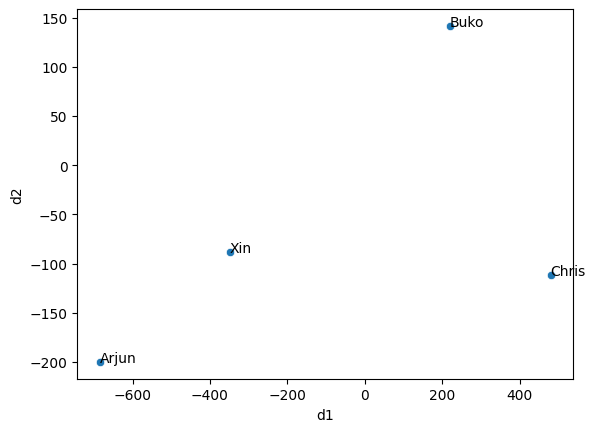

```python
labelled_scatterplot(data=tsne_labelled, x='d1', y='d2', labs='who')
```

Difference between t-SNEA and PCA

```python
churn_data = pd.read_csv("./customer_churn.csv")
churn_data.head(3)
```

|  | Call Failure | Complaints | Subscription Length | Charge Amount | Seconds of Use | Frequency of use | Frequency of SMS | Distinct Called Numbers | Age Group | Tariff Plan | Status | Age | Customer Value | Churn |
| --- | --- | --- | --- | --- | --- | --- | --- | --- | --- | --- | --- | --- | --- | --- |
| 0 | 8 | 0 | 38 | 0 | 4370 | 71 | 5 | 17 | 3 | 1 | 1 | 30 | 197.640 | 0 |
| 1 | 0 | 0 | 39 | 0 | 318 | 5 | 7 | 4 | 2 | 1 | 2 | 25 | 46.035 | 0 |
| 2 | 10 | 0 | 37 | 0 | 2453 | 60 | 359 | 24 | 3 | 1 | 1 | 30 | 1536.520 | 0 |

```python
from sklearn.preprocessing import StandardScaler

X = churn_data.drop('Churn', axis=1)
y = churn_data['Churn']

scaler = StandardScaler()
X_norm = scaler.fit_transform(X)


pca = PCA(n_components=2)
X_pca = pca.fit_transform(X_norm)
```

```python
import plotly.express as px

fig = px.scatter(x=X_pca[:, 0], y=X_pca[:, 1], color=y)
fig.update_layout(
    title="PCA visualization of Customer Churn dataset",
    xaxis_title="First Principal Component",
    yaxis_title="Second Principal Component",
)
fig.show()
```

[output not shown]

```python
tsne = TSNE(n_components=2,perplexity=40, random_state=42)
X_tsne = tsne.fit_transform(X_norm)
```

```python
fig = px.scatter(x=X_tsne[:, 0], y=X_tsne[:, 1], color=y)
fig.update_layout(
    title="t-SNE visualization of Customer Churn dataset",
    xaxis_title="First t-SNE",
    yaxis_title="Second t-SNE",
)
fig.show()
```

[output not shown]

### t-SNE demo

https://cs.stanford.edu/people/karpathy/tsnejs/csvdemo.html

# In your groups

Let's read the CSV file of the music data we generated at the start of today's class:

```python
url = "https://docs.google.com/spreadsheets/d/e/2PACX-1vTRe8guKi6zKf4_rQr8BiNmb2-V1Qq72vV7ZqSQ9Upeo6TsBtgFyZ4kk_IJgGdXx6kPdJP6NC_s_HOO/pub?gid=0&single=true&output=csv"
music = pd.read_csv(url)
```

```python
music
```

|  | Name | Blues | Classical | Country | Electronic | Folk | Hip Hop | Jazz | Latin | Pop | Rock |
| --- | --- | --- | --- | --- | --- | --- | --- | --- | --- | --- | --- |
| 0 | Alex T | 8 | 6 | 9 | 9 | 9 | 10 | 8 | 8 | 9 | 10 |
| 1 | Anne Chang | 8 | 10 | 3 | 8 | 8 | 5 | 8 | 7 | 5 | 5 |
| 2 | Arthur C. | 5 | 9 | 4 | 8 | 8 | 5 | 5 | 5 | 5 | 5 |
| 3 | Athena Fan | 5 | 3 | 5 | 8 | 8 | 7 | 5 | 4 | 9 | 9 |
| 4 | Bella | 5 | 5 | 4 | 7 | 5 | 8 | 3 | 8 | 10 | 6 |
| ... | ... | ... | ... | ... | ... | ... | ... | ... | ... | ... | ... |
| 68 | Paolo M | 5 | 9 | 10 | 10 | 3 | 7 | 3 | 3 | 6 | 9 |
| 69 | Aryan | 7 | 9 | 4 | 8 | 8 | 10 | 7 | 4 | 8 | 9 |
| 70 | Chris P | 7 | 7 | 1 | 3 | 3 | 5 | 7 | 6 | 5 | 10 |
| 71 | Matt C | 6 | 6 | 4 | 8 | 8 | 6 | 6 | 7 | 8 | 10 |
| 72 | YxG | 5 | 5 | 7 | 4 | 4 | 5 | 5 | 5 | 5 | 5 |

73 rows × 11 columns

```python
music.info()
```

```
<class 'pandas.core.frame.DataFrame'>
RangeIndex: 73 entries, 0 to 72
Data columns (total 11 columns):
 #   Column      Non-Null Count  Dtype
---  ------      --------------  -----
 0   Name        73 non-null     object
 1   Blues       73 non-null     int64
 2   Classical   73 non-null     int64
 3   Country     73 non-null     int64
 4   Electronic  73 non-null     int64
 5   Folk        73 non-null     int64
 6   Hip Hop     73 non-null     int64
 7   Jazz        73 non-null     int64
 8   Latin       73 non-null     int64
 9   Pop         73 non-null     int64
 10  Rock        73 non-null     int64
dtypes: int64(10), object(1)
memory usage: 6.4+ KB
```

```python
music.describe()
```

|  | Blues | Classical | Country | Electronic | Folk | Hip Hop | Jazz | Latin | Pop | Rock |
| --- | --- | --- | --- | --- | --- | --- | --- | --- | --- | --- |
| count | 73.000000 | 73.000000 | 73.000000 | 73.000000 | 73.000000 | 73.000000 | 73.000000 | 73.000000 | 73.000000 | 73.000000 |
| mean | 5.863014 | 6.671233 | 5.904110 | 5.616438 | 5.219178 | 6.465753 | 6.150685 | 4.958904 | 7.424658 | 6.780822 |
| std | 1.995238 | 2.297673 | 2.561273 | 2.700978 | 2.310884 | 2.500457 | 2.246425 | 2.318035 | 2.114223 | 2.804988 |
| min | 1.000000 | 2.000000 | 1.000000 | 0.000000 | 1.000000 | 0.000000 | 1.000000 | 0.000000 | 2.000000 | 1.000000 |
| 25% | 5.000000 | 5.000000 | 4.000000 | 3.000000 | 4.000000 | 5.000000 | 5.000000 | 3.000000 | 5.000000 | 5.000000 |
| 50% | 6.000000 | 7.000000 | 6.000000 | 6.000000 | 5.000000 | 7.000000 | 6.000000 | 5.000000 | 8.000000 | 7.000000 |
| 75% | 7.000000 | 9.000000 | 8.000000 | 8.000000 | 7.000000 | 8.000000 | 8.000000 | 6.000000 | 9.000000 | 9.000000 |
| max | 10.000000 | 10.000000 | 10.000000 | 10.000000 | 10.000000 | 10.000000 | 10.000000 | 10.000000 | 10.000000 | 10.000000 |

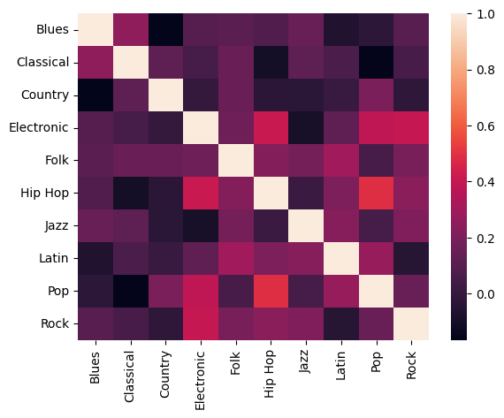

```python
sns.heatmap(music.corr(numeric_only=True))
```

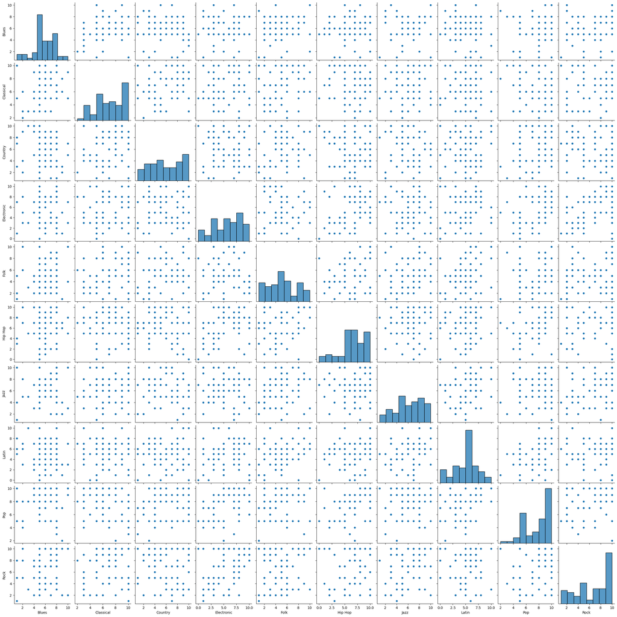

```python
sns.pairplot(music)
```

## Task

Create X (features matrix) and y (labels matrix) from the `music` dataframe:

```python
# insert your code here
music = music.dropna()
X = music.drop('Name', axis=1)
X
```

|  | Blues | Classical | Country | Electronic | Folk | Hip Hop | Jazz | Latin | Pop | Rock |
| --- | --- | --- | --- | --- | --- | --- | --- | --- | --- | --- |
| 0 | 8 | 6 | 9 | 9 | 9 | 10 | 8 | 8 | 9 | 10 |
| 1 | 8 | 10 | 3 | 8 | 8 | 5 | 8 | 7 | 5 | 5 |
| 2 | 5 | 9 | 4 | 8 | 8 | 5 | 5 | 5 | 5 | 5 |
| 3 | 5 | 3 | 5 | 8 | 8 | 7 | 5 | 4 | 9 | 9 |
| 4 | 5 | 5 | 4 | 7 | 5 | 8 | 3 | 8 | 10 | 6 |
| ... | ... | ... | ... | ... | ... | ... | ... | ... | ... | ... |
| 68 | 5 | 9 | 10 | 10 | 3 | 7 | 3 | 3 | 6 | 9 |
| 69 | 7 | 9 | 4 | 8 | 8 | 10 | 7 | 4 | 8 | 9 |
| 70 | 7 | 7 | 1 | 3 | 3 | 5 | 7 | 6 | 5 | 10 |
| 71 | 6 | 6 | 4 | 8 | 8 | 6 | 6 | 7 | 8 | 10 |
| 72 | 5 | 5 | 7 | 4 | 4 | 5 | 5 | 5 | 5 | 5 |

73 rows × 10 columns

```python
y = music.Name
```

## Task

Perform a multi-dimensional scaling on the music data. Should you use metric or non-metric MDS? Do the results differ between metric and non-metric? Visualize your results.

```python
# Insert your code here
npos = nmds.fit_transform(X)
npos
```

```
array([[ 3.52195400e-01, -1.20119737e-01],
       [-3.05992807e-01, -1.78461788e-02],
       [ 3.01311899e-01, -2.87454580e-01],
       [ 1.69598164e-01, -3.75179572e-01],
       [-4.01849885e-01, -2.76028520e-02],
       [ 8.72096320e-02,  1.14170116e-01],
       [ 2.04956502e-01,  4.61075524e-01],
       [ 5.98652178e-02, -1.94959412e-01],
       [ 3.03059366e-01, -2.39555032e-01],
       [-1.23546464e-02, -4.26194305e-01],
       [-3.51757334e-01,  3.89433910e-01],
       [ 3.39919873e-01,  1.09880533e-01],
       [-3.34072185e-02, -3.43557373e-01],
       [-3.03336704e-01, -2.43201174e-01],
       [ 1.04308001e-01,  2.00412604e-01],
       [ 1.99707553e-01, -2.39745736e-01],
       [ 4.60114840e-01,  1.91291380e-01],
       [ 1.41387208e-01,  6.45932313e-02],
       [-2.02536012e-02, -2.69627412e-01],
       [-1.33748353e-01,  2.42416556e-01],
       [-4.25416631e-01, -3.10678979e-01],
       [-3.85715410e-01, -3.65495812e-01],
       [ 4.10528797e-01,  1.69250098e-01],
       [-1.29391082e-05, -3.89028948e-01],
       [ 5.77508250e-02, -1.14824547e-01],
       [-2.91110776e-01, -1.38784476e-01],
       [-3.43268154e-02,  2.79555555e-02],
       [ 1.16554803e-01, -4.17292672e-01],
       [-9.53291725e-02,  4.56878469e-02],
       [ 5.59792324e-02,  4.10572742e-01],
       [ 1.52260783e-01, -3.26391457e-01],
       [-4.14791214e-01,  8.57264535e-02],
       [-4.76928488e-01,  4.45315196e-02],
       [ 4.74827036e-01,  8.17952680e-02],
       [-7.92655885e-02,  9.25665778e-02],
       [-1.10673586e-02, -5.47865900e-03],
       [ 4.64061747e-01, -1.33815218e-01],
       [ 5.14921594e-01,  4.16515775e-01],
       [-2.92107633e-01, -4.30206646e-01],
       [-3.82017341e-01, -4.58069941e-01],
```

[output cut: 18 more lines]

```
       [ 5.17074610e-01, -4.93938606e-01],
       [-2.05958345e-01,  6.37428415e-01],
       [ 6.17670944e-01,  7.77843081e-02],
       [ 2.23999933e-01, -8.93170039e-02],
       [-2.46775616e-01, -2.61976485e-01],
       [ 2.60509883e-01,  3.24737017e-01],
       [ 4.18467903e-01,  3.79930447e-01],
       [-5.58083323e-01, -8.72763701e-02],
       [-6.27803890e-01,  3.14471367e-03],
       [-2.19948948e-02,  5.45131870e-01],
       [-2.09205040e-01, -5.67764621e-01],
       [-4.51834066e-01,  3.67003296e-01],
       [ 1.97123863e-01, -5.92302138e-01],
       [-5.87717981e-01,  2.66045005e-01],
       [-6.07142576e-01,  4.73053002e-01]])
```

```python
npos_labelled = pd.concat([pd.DataFrame({'who': y}), pd.DataFrame(npos)], axis=1)
npos_labelled.columns = ['who', 'mds1', 'mds2']
npos_labelled
```

|  | who | mds1 | mds2 |
| --- | --- | --- | --- |
| 0 | Alex T | 0.352195 | -0.120120 |
| 1 | Anne Chang | -0.305993 | -0.017846 |
| 2 | Arthur C. | 0.301312 | -0.287455 |
| 3 | Athena Fan | 0.169598 | -0.375180 |
| 4 | Bella | -0.401850 | -0.027603 |
| ... | ... | ... | ... |
| 68 | Paolo M | -0.209205 | -0.567765 |
| 69 | Aryan | -0.451834 | 0.367003 |
| 70 | Chris P | 0.197124 | -0.592302 |
| 71 | Matt C | -0.587718 | 0.266045 |
| 72 | YxG | -0.607143 | 0.473053 |

73 rows × 3 columns

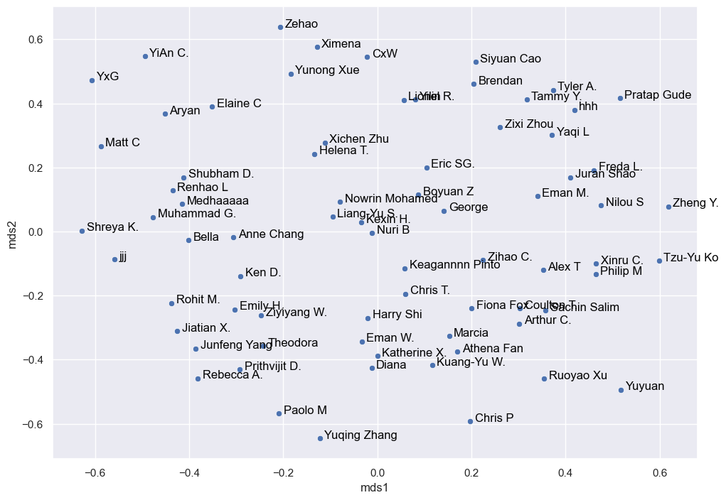

```python
sns.set(rc={'figure.figsize':(11.7,8.27)})
labelled_scatterplot(npos_labelled, 'mds1', 'mds2', 'who')
```

## Task

Perform a principal components analysis (PCA) on the music data. Do you think you should scale the data before you do the PCA? How many principal components should you retain (hint: look at a scree plot and/or eigenvalues, a.k.a. the explained_variance_ attribute of the PCA model). Visualize your results.

```python
# insert your code here
pca = PCA(n_components=3)
X_pca = pca.fit_transform(X)
X_pca
```

```
array([[-7.70906441, -2.39530344, -2.0745324 ],
       [-0.48401541, -3.97888872,  1.85949837],
       [ 0.48663566, -1.31198041,  0.8456726 ],
       [-3.35585142,  2.65093329,  0.39108901],
       [-1.92120204,  3.6520221 , -2.22744933],
       [ 4.26588944, -0.13226039, -1.80515377],
       [-4.90031575, -3.18399648,  1.72133326],
       [ 1.57019546, -5.90282916,  1.04007595],
       [-5.60945475, -1.98613943,  0.64357079],
       [ 1.32593359,  6.63173212, -4.99763304],
       [ 1.39092269,  0.44356054,  1.81398271],
       [-2.79934939,  1.09369129,  0.54322166],
       [ 0.11339729,  3.45249917,  5.7360248 ],
       [ 1.62597496, -0.93054581,  2.8597045 ],
       [-4.41680513,  4.48836395,  2.43836214],
       [-3.35585142,  2.65093329,  0.39108901],
       [ 2.27913811,  0.98376658, -3.71168939],
       [-1.86712278,  2.66070162, -0.43546642],
       [-5.78909425, -1.39337436, -2.32182271],
       [-4.29413123, -3.32877722, -1.3420345 ],
       [ 1.85180225, -1.38242847,  0.12471539],
       [ 5.58884453, -3.17344127, -1.61903043],
       [-4.24653743, -3.51599336, -0.02628623],
       [-0.62861319,  0.48648899, -2.14430008],
       [-4.89342893, -4.24640421, -1.39165991],
       [-1.36337119,  5.08088672,  3.02000008],
       [ 2.23477787,  1.76541115,  7.89259865],
       [ 6.72880031, -6.53587033,  0.10172236],
       [ 1.11538178, -1.96232553, -0.66346738],
       [-4.54370183, -3.75871687,  0.35240203],
       [-2.02089479,  3.26402343, -3.74749705],
       [-3.50965803,  1.68129576, -2.84435617],
       [ 5.8887411 ,  2.80115687, -1.17600863],
       [ 0.39433146,  1.89850038, -0.74524377],
       [-3.44337624, -4.05291151, -7.63038493],
       [ 4.62879689, -2.64024023, -0.53805415],
       [ 2.60078663, -2.95512531,  3.03481938],
       [ 3.02574594,  1.09796723,  0.08125521],
       [-1.66864155, -1.3073451 ,  1.0484264 ],
       [ 9.18811367, -0.39363784, -3.40679497],
```

[output cut: 18 more lines]

```
       [ 1.70774207,  2.33600035, -1.49825949],
       [-1.4650237 ,  2.48119803, -0.53924117],
       [ 4.21443596, -2.60202523,  0.11712261],
       [-2.19532699,  4.55609387,  0.15002162],
       [ 7.05593873, -0.85885568, -1.50561854],
       [ 2.58620046,  1.93251621,  0.52343889],
       [-2.93798027, -1.71744738, -1.05746311],
       [-2.46305103, -3.48599345, -2.18539501],
       [ 4.85382734,  3.86417649,  3.7247957 ],
       [-0.73892255,  1.79691236,  3.53176788],
       [-2.1506286 ,  1.38648572,  0.33987891],
       [-4.96310709, -0.97994834,  2.16222971],
       [ 1.71878119, -0.64526821,  5.67727542],
       [-3.90819536, -0.58998687,  1.52992905],
       [ 3.75679308,  0.76816111, -0.96564689]])
```

```python
pca.explained_variance_ratio_
```

```
array([0.25030977, 0.13720602, 0.13657906])
```

### Visualizing principal components

```python
def pca_results(data, columns, pca):

    # Dimension indexing
    dimensions = ['Dimension {}'.format(i) for i in range(1, len(pca.components_)+1)]

    # PCA components
    components = pd.DataFrame(np.round(pca.components_, 4), columns=columns)
    components.index = dimensions

    # PCA explained variance
    ratios = pca.explained_variance_ratio_.reshape(len(pca.components_), 1)
    variance_ratios = pd.DataFrame(np.round(ratios, 4), columns = ['Explained Variance'])
    variance_ratios.index = dimensions

    # Create a bar plot visualization
    fig, ax = plt.subplots(figsize=(14,8))

    # Plot the feature weights as a function of the components
    components.plot(ax=ax, kind='bar')
    ax.set_ylabel("Feature Weights")
    ax.set_xticklabels(dimensions, rotation=0)

    # Display the explained variance ratios
    for i, ev in enumerate(pca.explained_variance_ratio_):
        ax.text(i-0.40, ax.get_ylim()[1] + 0.05, "Explained Variance\n %.4f"%(ev))

    # Return a concatenated DataFrame
    return pd.concat([variance_ratios, components], axis=1)
```

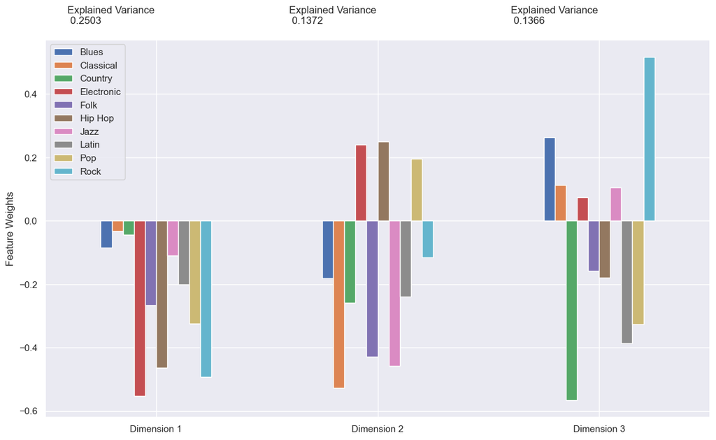

```python
pcax = pca_results(X_pca, music.drop('Name', axis=1).columns, pca)
```

## Task

Perform a t-SNE analysis of the music data. Experiment with different hyperparameters (i.e. perplexity and n_iter) to see how your solution changes. Visualize your results.

```python
# Insert your code here
X_tsne = tsne.fit_transform(X)
```

## Task

Compare the three analyses (MDS, PCA, and t-SNE). Comment on similarities and differences. What do you think the best technique is to use with the music data?

Insert your answer here.

## Stretch task

Use a Pipeline to perform a PCA on the music data.

## A few words about pipelines

Consider the following pipeline:

```python
from sklearn.pipeline import Pipeline
from sklearn.preprocessing import StandardScaler
from sklearn.decomposition import PCA

pipe = Pipeline([
    ('scale',StandardScaler()),
    ('pca', PCA(n_components=5,random_state=42)),
])
```

```python
pipe
```

```
Pipeline(steps=[('scale', StandardScaler()),
                ('pca', PCA(n_components=5, random_state=42))])
```

The pipeline can be queried by using `get_params()`:

```python
pipe.get_params()
```

```
{'memory': None,
 'steps': [('scale', StandardScaler()),
  ('pca', PCA(n_components=5, random_state=42))],
 'verbose': False,
 'scale': StandardScaler(),
 'pca': PCA(n_components=5, random_state=42),
 'scale__copy': True,
 'scale__with_mean': True,
 'scale__with_std': True,
 'pca__copy': True,
 'pca__iterated_power': 'auto',
 'pca__n_components': 5,
 'pca__n_oversamples': 10,
 'pca__power_iteration_normalizer': 'auto',
 'pca__random_state': 42,
 'pca__svd_solver': 'auto',
 'pca__tol': 0.0,
 'pca__whiten': False}
```

The `named_steps` attribute holds (unsurprisingly) the named steps of the pipeline:

```python
pipe.named_steps
```

```
{'scale': StandardScaler(), 'pca': PCA(n_components=5, random_state=42)}
```

The steps themselves can be accessed as attributes of the `named_steps` property:

```python
pipe.named_steps.pca
```

```
PCA(n_components=5, random_state=42)
```

And specifics about the step can be modified by assigning new values to them:

```python
pipe.named_steps.pca.n_components=3
```

```python
pipe.named_steps.pca
```

```
PCA(n_components=3, random_state=42)
```